# IS-804 Project Report - Energy Efficient Data

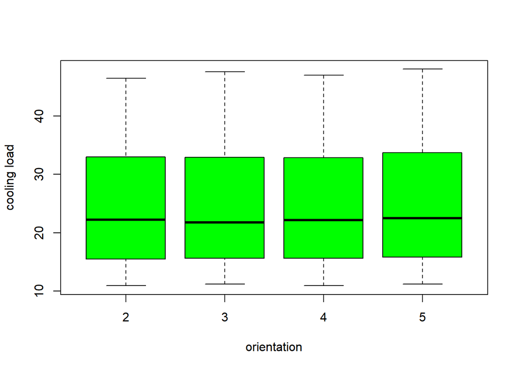

```r
plot(qual_orientation, cooling_load, col="green", varwidth=T, xlab='orientation', ylab='cooling load')
```

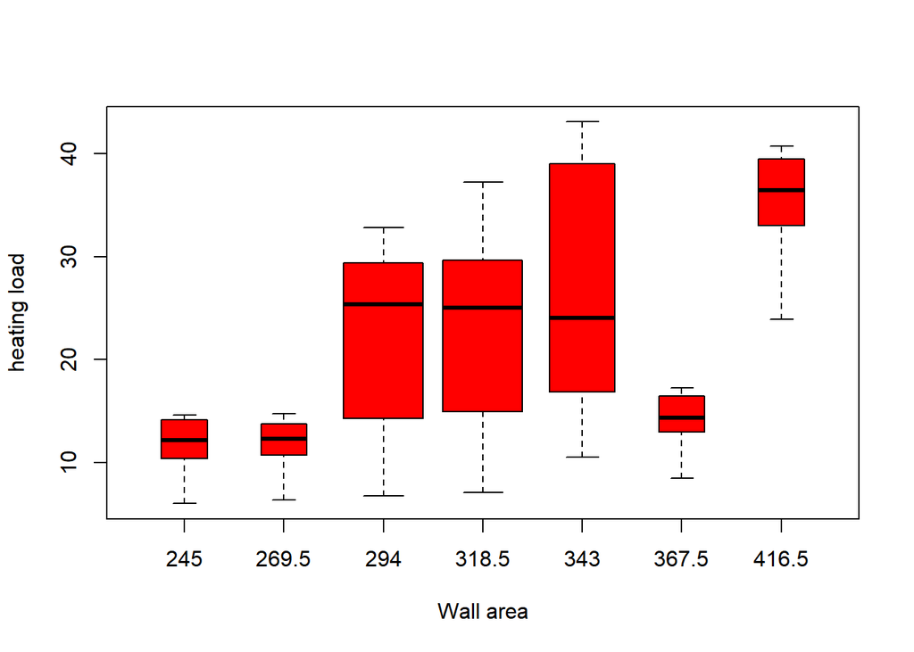

```r
plot(qual_wall_area, heating_load, col="red", varwidth=T, xlab='Wall area', ylab='heating load')
```

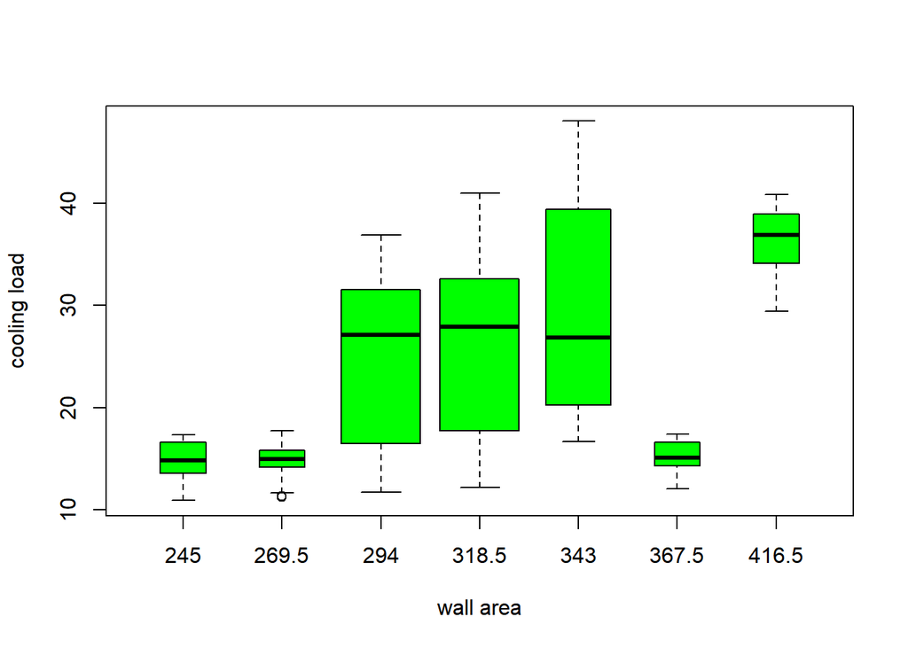

```r
plot(qual_wall_area, cooling_load, col="green", varwidth=T, xlab='wall area', ylab='cooling load')
```

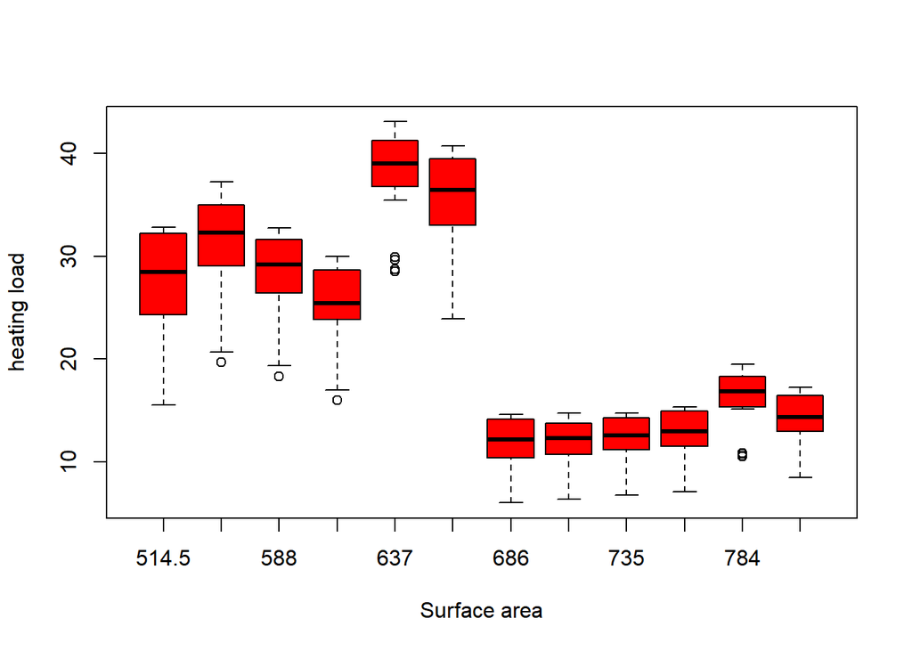

```r
plot(qual_surface_area, heating_load, col="red", varwidth=T, xlab='Surface area', ylab='heating load')
```

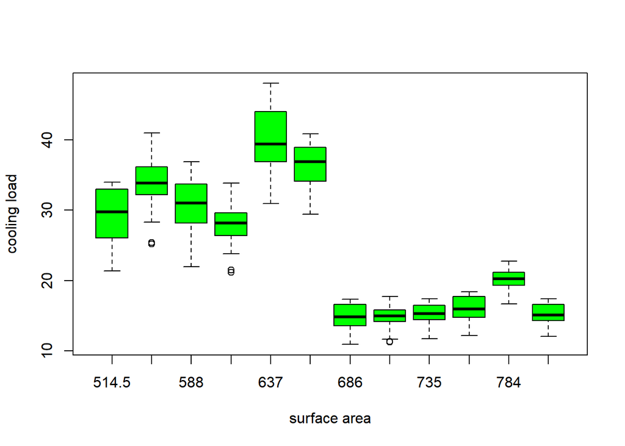

```r
plot(qual_surface_area, cooling_load, col="green", varwidth=T, xlab='surface area', ylab='cooling load')
```

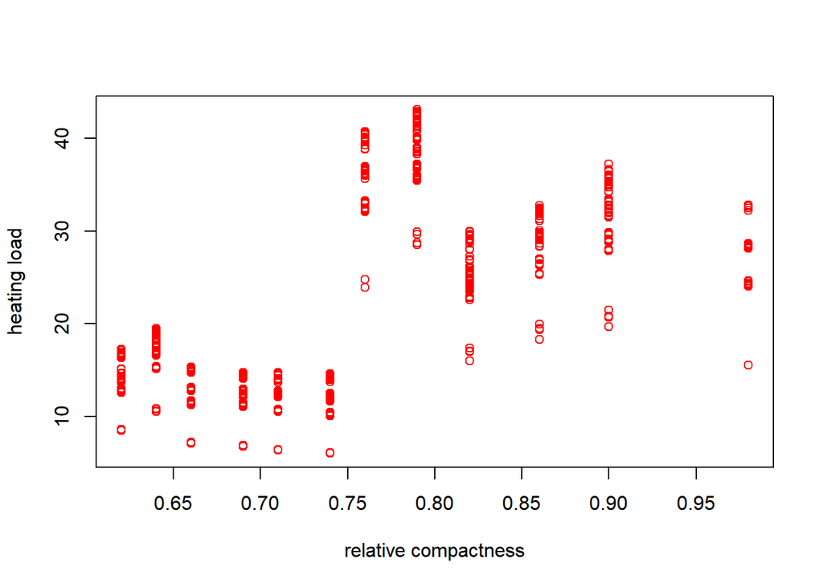

```r
plot(relative_compactness, heating_load, col="red", varwidth=T, xlab='relative compactness', ylab='heating load')
```

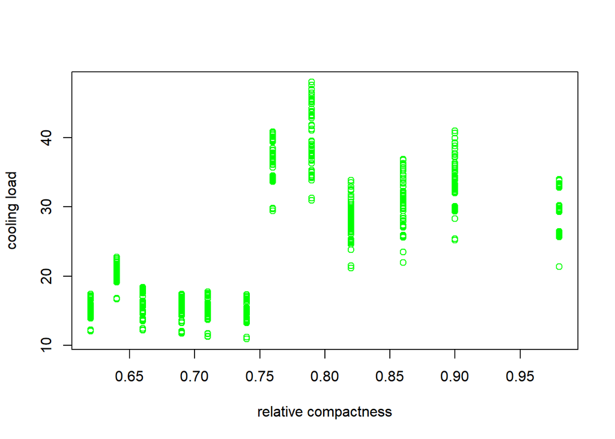

```r
plot(relative_compactness, cooling_load, col="green", varwidth=T, xlab='relative compactness', ylab='cooling load')
```

Above observations are obvious from the figures.

#### Histogram

Histograms shows the heating and cooling load distribution in the dataset.

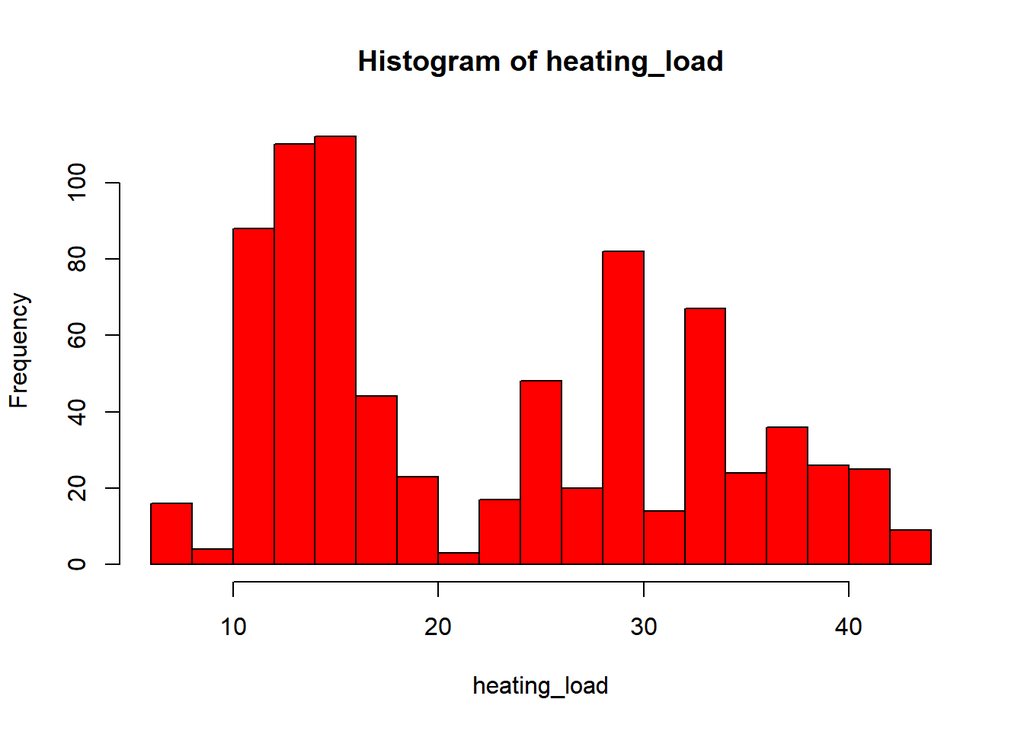

```r
hist(heating_load,col="red",breaks=15)
```

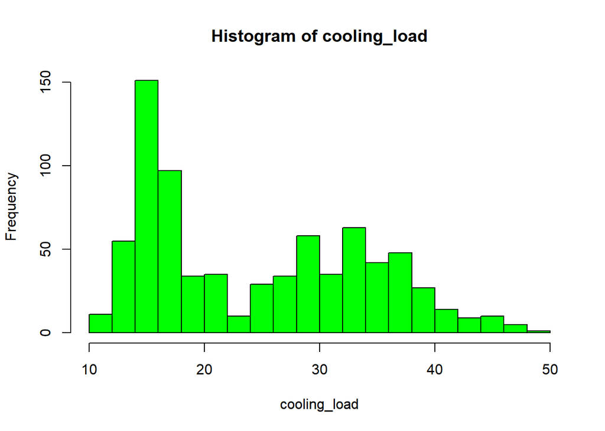

```r
hist(cooling_load,col="green",breaks=15)
```

#### Scatter plot matrix

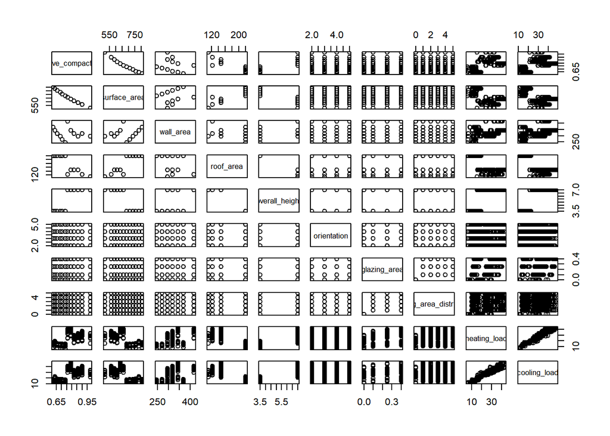

```r
pairs(energy) #pairs() function creates a scatterplot matrix
```

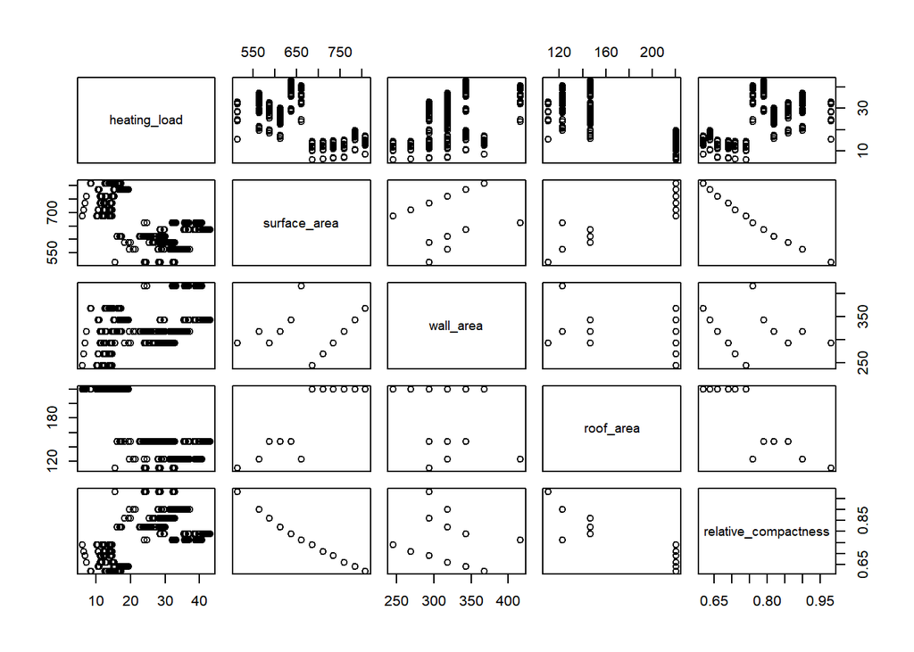

```r
pairs(~ heating_load + surface_area + wall_area + roof_area + relative_compactness, energy)
```

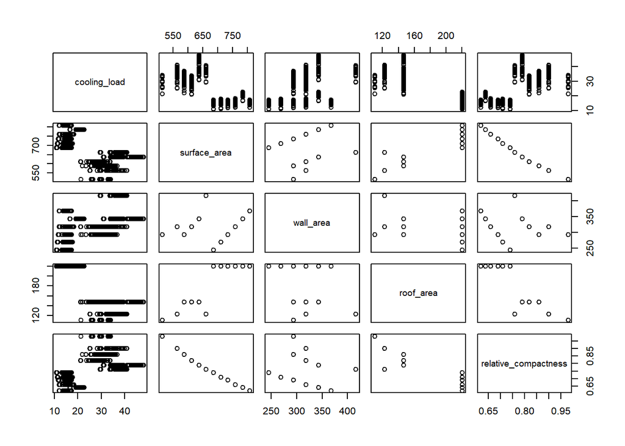

```r
pairs(~ cooling_load + surface_area + wall_area + roof_area + relative_compactness, energy)
```

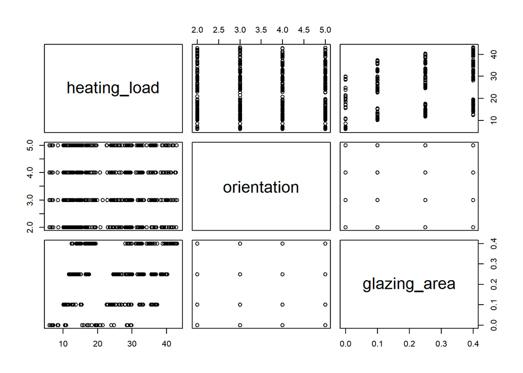

```r
pairs(~ heating_load + orientation + glazing_area, energy)
```

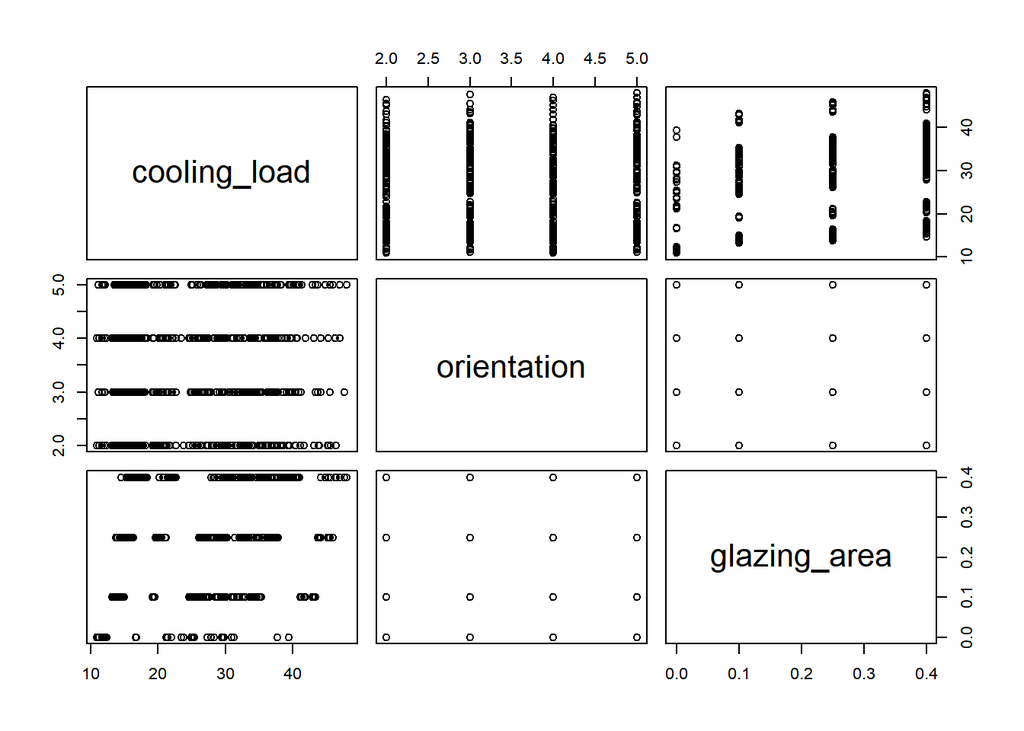

```r
pairs(~ cooling_load + orientation + glazing_area, energy)
```

#### Co-Relation

```r
cor(energy)
```

```
##                           relative_compactness  surface_area  wall_area
## relative_compactness              1.000000e+00 -9.919015e-01 -0.2037817
## surface_area                     -9.919015e-01  1.000000e+00  0.1955016
## wall_area                        -2.037817e-01  1.955016e-01  1.0000000
## roof_area                        -8.688234e-01  8.807195e-01 -0.2923165
## overall_height                    8.277473e-01 -8.581477e-01  0.2809757
## orientation                       0.000000e+00  0.000000e+00  0.0000000
## glazing_area                      7.617400e-20  4.664140e-20  0.0000000
## glazing_area_distribution         0.000000e+00  0.000000e+00  0.0000000
## heating_load                      6.222722e-01 -6.581202e-01  0.4556712
## cooling_load                      6.343391e-01 -6.729989e-01  0.4271170
##                               roof_area overall_height  orientation
## relative_compactness      -8.688234e-01      0.8277473  0.000000000
## surface_area               8.807195e-01     -0.8581477  0.000000000
## wall_area                 -2.923165e-01      0.2809757  0.000000000
## roof_area                  1.000000e+00     -0.9725122  0.000000000
## overall_height            -9.725122e-01      1.0000000  0.000000000
## orientation                0.000000e+00      0.0000000  1.000000000
## glazing_area              -1.197187e-19      0.0000000  0.000000000
## glazing_area_distribution  0.000000e+00      0.0000000  0.000000000
## heating_load              -8.618283e-01      0.8894307 -0.002586534
## cooling_load              -8.625466e-01      0.8957852  0.014289598
##                            glazing_area glazing_area_distribution
## relative_compactness       7.617400e-20                0.00000000
## surface_area               4.664140e-20                0.00000000
## wall_area                  0.000000e+00                0.00000000
## roof_area                 -1.197187e-19                0.00000000
## overall_height             0.000000e+00                0.00000000
## orientation                0.000000e+00                0.00000000
## glazing_area               1.000000e+00                0.21296422
## glazing_area_distribution  2.129642e-01                1.00000000
## heating_load               2.698410e-01                0.08736759
## cooling_load               2.075050e-01                0.05052512
##                           heating_load cooling_load
## relative_compactness       0.622272179   0.63433907
## surface_area              -0.658120227  -0.67299893
## wall_area                  0.455671157   0.42711700
## roof_area                 -0.861828253  -0.86254660
## overall_height             0.889430674   0.89578517
## orientation               -0.002586534   0.01428960
## glazing_area               0.269840996   0.20750499
## glazing_area_distribution  0.087367594   0.05052512
## heating_load               1.000000000   0.97586181
## cooling_load               0.975861813   1.00000000
```

#### summary of output variables

```r
summary (heating_load)
```

```
##    Min. 1st Qu.  Median    Mean 3rd Qu.    Max.
##    6.01   12.99   18.95   22.31   31.67   43.10
```

```r
summary(cooling_load)
```

```
##    Min. 1st Qu.  Median    Mean 3rd Qu.    Max.
##   10.90   15.62   22.08   24.59   33.13   48.03
```

### Chapter 3

#### Linear regression

linear regression is applied with all the input variables.

```r
lm.fit=lm(heating_load~relative_compactness+ surface_area + wall_area + orientation + roof_area + overall_height + glazing_area+ glazing_area_distribution,data=energy)
lm.fit
```

```
##
## Call:
## lm(formula = heating_load ~ relative_compactness + surface_area +
##     wall_area + orientation + roof_area + overall_height + glazing_area +
##     glazing_area_distribution, data = energy)
##
## Coefficients:
##               (Intercept)       relative_compactness
##                  84.01452                  -64.77399
##              surface_area                  wall_area
##                  -0.08729                    0.06081
##               orientation                  roof_area
##                  -0.02333                         NA
##            overall_height               glazing_area
##                   4.16994                   19.93268
## glazing_area_distribution
##                   0.20377
```

```r
summary(lm.fit)
```

```
##
## Call:
## lm(formula = heating_load ~ relative_compactness + surface_area +
##     wall_area + orientation + roof_area + overall_height + glazing_area +
##     glazing_area_distribution, data = energy)
##
## Residuals:
##     Min      1Q  Median      3Q     Max
## -9.8965 -1.3196 -0.0252  1.3532  7.7052
##
## Coefficients: (1 not defined because of singularities)
##                             Estimate Std. Error t value Pr(>|t|)
## (Intercept)                84.014521  19.033607   4.414 1.16e-05 ***
## relative_compactness      -64.773991  10.289445  -6.295 5.19e-10 ***
## surface_area               -0.087290   0.017075  -5.112 4.04e-07 ***
## wall_area                   0.060813   0.006648   9.148  < 2e-16 ***
## orientation                -0.023328   0.094705  -0.246  0.80550
## roof_area                         NA         NA      NA       NA
## overall_height              4.169939   0.337990  12.337  < 2e-16 ***
## glazing_area               19.932680   0.813986  24.488  < 2e-16 ***
## glazing_area_distribution   0.203772   0.069918   2.914  0.00367 **
## ---
## Signif. codes:  0 '***' 0.001 '**' 0.01 '*' 0.05 '.' 0.1 ' ' 1
##
## Residual standard error: 2.934 on 760 degrees of freedom
## Multiple R-squared:  0.9162, Adjusted R-squared:  0.9154
## F-statistic:  1187 on 7 and 760 DF,  p-value: < 2.2e-16
```

```r
names(lm.fit)
```

```
##  [1] "coefficients"  "residuals"     "effects"       "rank"
##  [5] "fitted.values" "assign"        "qr"            "df.residual"
##  [9] "xlevels"       "call"          "terms"         "model"
```

```r
coef(lm.fit)
```

```
##               (Intercept)      relative_compactness
##               84.01452119              -64.77399149
##              surface_area                 wall_area
##               -0.08729027                0.06081334
##               orientation                 roof_area
##               -0.02332813                        NA
##            overall_height              glazing_area
##                4.16993881               19.93268018
## glazing_area_distribution
##                0.20377177
```

```r
confint(lm.fit) # confidence interval for the coefficient estimates
```

```
##                                  2.5 %       97.5 %
## (Intercept)                46.64983259 121.37920978
## relative_compactness      -84.97310070 -44.57488228
## surface_area               -0.12081099  -0.05376956
## wall_area                   0.04776285   0.07386383
## orientation                -0.20924198   0.16258573
## roof_area                           NA           NA
## overall_height              3.50643397   4.83344366
## glazing_area               18.33475226  21.53060810
## glazing_area_distribution   0.06651684   0.34102670
```

```r
lm.fit2=lm(heating_load~relative_compactness+  wall_area + orientation + roof_area + glazing_area+ glazing_area_distribution,data=energy)
lm.fit2
```

```
##
## Call:
## lm(formula = heating_load ~ relative_compactness + wall_area +
##     orientation + roof_area + glazing_area + glazing_area_distribution,
##     data = energy)
##
## Coefficients:
##               (Intercept)       relative_compactness
##                 261.37820                 -145.94369
##                 wall_area                orientation
##                  -0.12559                   -0.02333
##                 roof_area               glazing_area
##                  -0.52496                   19.93268
## glazing_area_distribution
##                   0.20377
```

```r
summary(lm.fit2)
```

```
##
## Call:
## lm(formula = heating_load ~ relative_compactness + wall_area +
##     orientation + roof_area + glazing_area + glazing_area_distribution,
##     data = energy)
##
## Residuals:
##     Min      1Q  Median      3Q     Max
## -9.8468 -2.0124 -0.2825  1.4104  9.1552
##
## Coefficients:
##                             Estimate Std. Error t value Pr(>|t|)
## (Intercept)                261.37820   13.65752  19.138  < 2e-16 ***
## relative_compactness      -145.94369    8.66165 -16.849  < 2e-16 ***
## wall_area                   -0.12559    0.01087 -11.550  < 2e-16 ***
## orientation                 -0.02333    0.10369  -0.225  0.82205
## roof_area                   -0.52496    0.02077 -25.279  < 2e-16 ***
## glazing_area                19.93268    0.89119  22.366  < 2e-16 ***
## glazing_area_distribution    0.20377    0.07655   2.662  0.00793 **
## ---
## Signif. codes:  0 '***' 0.001 '**' 0.01 '*' 0.05 '.' 0.1 ' ' 1
##
## Residual standard error: 3.213 on 761 degrees of freedom
## Multiple R-squared:  0.8994, Adjusted R-squared:  0.8986
## F-statistic:  1134 on 6 and 761 DF,  p-value: < 2.2e-16
```

```r
names(lm.fit2)
```

```
##  [1] "coefficients"  "residuals"     "effects"       "rank"
##  [5] "fitted.values" "assign"        "qr"            "df.residual"
##  [9] "xlevels"       "call"          "terms"         "model"
```

```r
coef(lm.fit2)
```

```
##               (Intercept)      relative_compactness
##              261.37819945             -145.94368872
##                 wall_area               orientation
##               -0.12558736               -0.02332812
##                 roof_area              glazing_area
##               -0.52495536               19.93268018
## glazing_area_distribution
##                0.20377177
```

```r
confint(lm.fit2)
```

```
##                                   2.5 %       97.5 %
## (Intercept)                234.56730908  288.1890898
## relative_compactness      -162.94725485 -128.9401226
## wall_area                   -0.14693212   -0.1042426
## orientation                 -0.22687603    0.1802198
## roof_area                   -0.56572229   -0.4841884
## glazing_area                18.18318773   21.6821726
## glazing_area_distribution    0.05349812    0.3540454
```

Second model provides lower $R^2$ value.

#### Residual plots

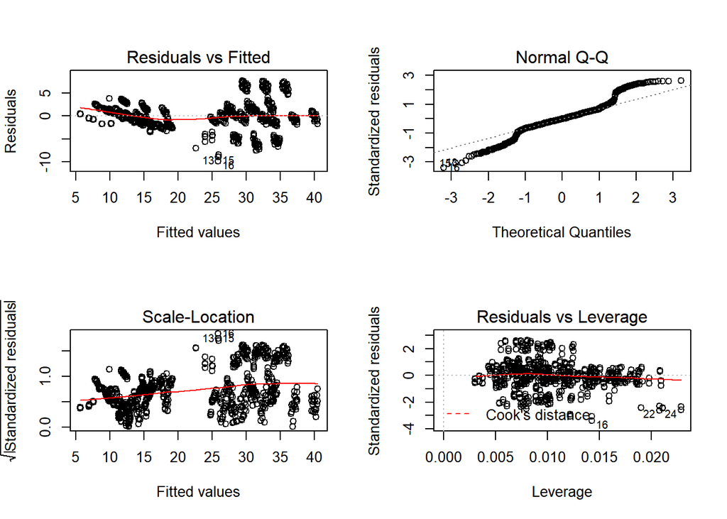

```r
par(mfrow=c(2,2))
plot(lm.fit)
abline(lm.fit,lwd=5,col="red" )
```

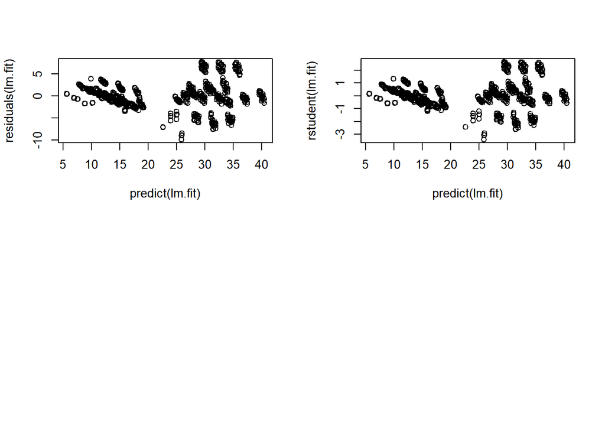

```r
plot(predict(lm.fit), residuals(lm.fit))
plot(predict(lm.fit), rstudent(lm.fit))
```

There might be some evidence of heteroscedasticity as it appears a funnel shape in residual vs. fitted value plot. After transforming the output variables with taking logarithm.

```r
lm.fit=lm(log(heating_load)~relative_compactness+ surface_area + wall_area + orientation + roof_area + overall_height + glazing_area+ glazing_area_distribution,data=energy)
lm.fit
```

```
##
## Call:
## lm(formula = log(heating_load) ~ relative_compactness + surface_area +
##     wall_area + orientation + roof_area + overall_height + glazing_area +
##     glazing_area_distribution, data = energy)
##
## Coefficients:
##               (Intercept)       relative_compactness
##                -0.5787874                  0.5623864
##              surface_area                  wall_area
##                 0.0014251                  0.0015991
##               orientation                  roof_area
##                -0.0008389                         NA
##            overall_height               glazing_area
##                 0.2665273                  1.0117131
## glazing_area_distribution
##                 0.0159934
```

```r
summary(lm.fit)
```

```
##
## Call:
## lm(formula = log(heating_load) ~ relative_compactness + surface_area +
##     wall_area + orientation + roof_area + overall_height + glazing_area +
##     glazing_area_distribution, data = energy)
##
## Residuals:
##      Min       1Q   Median       3Q      Max
## -0.35472 -0.05718  0.00176  0.06585  0.31204
##
## Coefficients: (1 not defined because of singularities)
##                             Estimate Std. Error t value Pr(>|t|)
## (Intercept)               -0.5787874  0.7806251  -0.741   0.4587
## relative_compactness       0.5623864  0.4220009   1.333   0.1830
## surface_area               0.0014251  0.0007003   2.035   0.0422 *
## wall_area                  0.0015991  0.0002727   5.865 6.70e-09 ***
## orientation               -0.0008389  0.0038841  -0.216   0.8290
## roof_area                         NA         NA      NA       NA
## overall_height             0.2665273  0.0138620  19.227  < 2e-16 ***
## glazing_area               1.0117131  0.0333840  30.305  < 2e-16 ***
## glazing_area_distribution  0.0159934  0.0028675   5.577 3.39e-08 ***
## ---
## Signif. codes:  0 '***' 0.001 '**' 0.01 '*' 0.05 '.' 0.1 ' ' 1
##
## Residual standard error: 0.1203 on 760 degrees of freedom
## Multiple R-squared:  0.9368, Adjusted R-squared:  0.9362
## F-statistic:  1610 on 7 and 760 DF,  p-value: < 2.2e-16
```

```r
names(lm.fit)
```

```
##  [1] "coefficients"  "residuals"     "effects"       "rank"
##  [5] "fitted.values" "assign"        "qr"            "df.residual"
##  [9] "xlevels"       "call"          "terms"         "model"
```

```r
coef(lm.fit)
```

```
##               (Intercept)      relative_compactness
##             -0.5787873931              0.5623863990
##              surface_area                 wall_area
##              0.0014250946              0.0015991130
##               orientation                 roof_area
##             -0.0008389492                        NA
##            overall_height              glazing_area
##              0.2665273333              1.0117131308
## glazing_area_distribution
##              0.0159934328
```

```r
confint(lm.fit)
```

```
##                                   2.5 %      97.5 %
## (Intercept)               -2.111225e+00 0.953650097
## relative_compactness      -2.660394e-01 1.390812204
## surface_area               5.030992e-05 0.002799879
## wall_area                  1.063873e-03 0.002134353
## orientation               -8.463832e-03 0.006785933
## roof_area                            NA          NA
## overall_height             2.393150e-01 0.293739649
## glazing_area               9.461773e-01 1.077248928
## glazing_area_distribution  1.036420e-02 0.021622667
```

Now the residual plot is as follows:

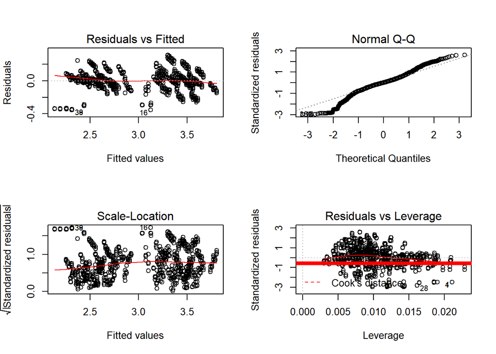

```r
par(mfrow=c(2,2))
plot(lm.fit)
abline(lm.fit,lwd=5,col="red" )
```

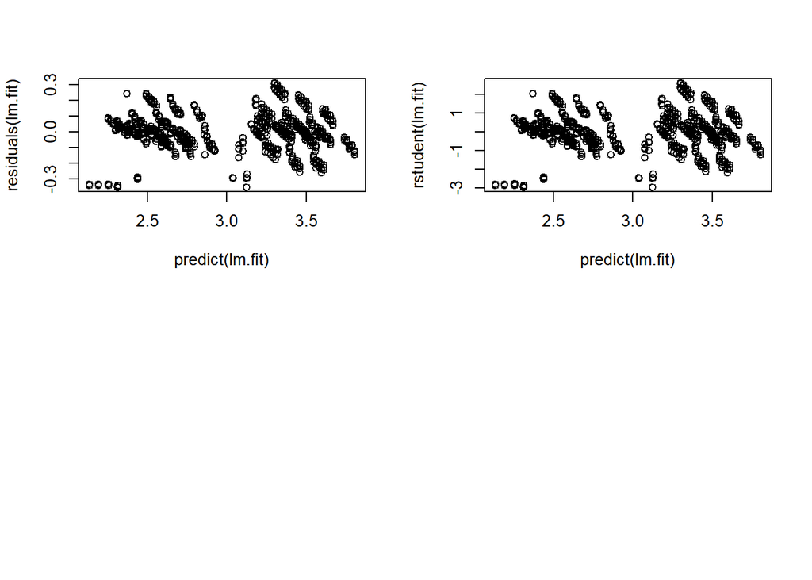

```r
plot(predict(lm.fit), residuals(lm.fit))
plot(predict(lm.fit), rstudent(lm.fit))
```

After transforming the funnel shape is removed and no evidence of heteroscedasticity is found.

#### Leverage statistics

Leverage statistics can be computed for any number of predictors using the hatvalues() function.

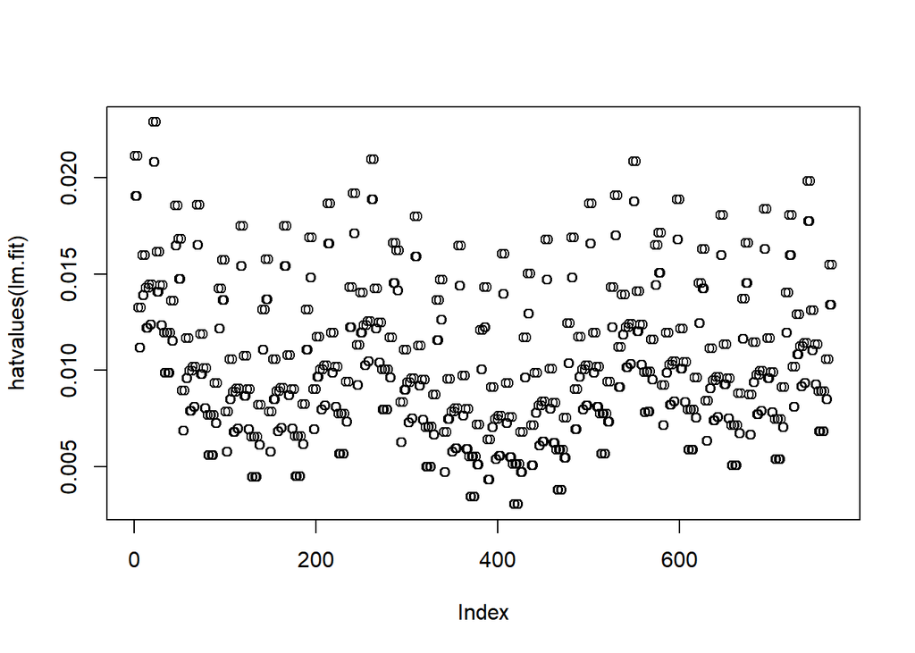

```r
plot(hatvalues(lm.fit))
```

To get the observation with maximum leverage statistics, following code can be used.

```r
which.max(hatvalues(lm.fit))
```

```
## 21
## 21
```

#### Multiple Linear Regression

To see how the heating and cooling load differs for the entire volume of the buildings, following model is built.

```r
lm.fit3=lm((heating_load) ~ surface_area * overall_height ,data=energy)
summary(lm.fit3)
```

```
##
## Call:
## lm(formula = (heating_load) ~ surface_area * overall_height,
##     data = energy)
##
## Residuals:
##      Min       1Q   Median       3Q      Max
## -16.2286  -2.1288   0.2706   2.2940   9.4924
##
## Coefficients:
##                               Estimate Std. Error t value Pr(>|t|)
## (Intercept)                 -16.106804   7.896794  -2.040   0.0417 *
## surface_area                  0.003855   0.010866   0.355   0.7229
## overall_height                1.905594   1.296516   1.470   0.1420
## surface_area:overall_height   0.007607   0.001884   4.037 5.96e-05 ***
## ---
## Signif. codes:  0 '***' 0.001 '**' 0.01 '*' 0.05 '.' 0.1 ' ' 1
##
## Residual standard error: 4.088 on 764 degrees of freedom
## Multiple R-squared:  0.8365, Adjusted R-squared:  0.8359
## F-statistic:  1303 on 3 and 764 DF,  p-value: < 2.2e-16
```

```r
lm.fit4=lm(cooling_load ~ surface_area * overall_height ,data=energy)
summary(lm.fit4)
```

```
##
## Call:
## lm(formula = cooling_load ~ surface_area * overall_height, data = energy)
##
## Residuals:
##      Min       1Q   Median       3Q      Max
## -12.8026  -2.2738  -0.1464   2.1960  12.7796
##
## Coefficients:
##                              Estimate Std. Error t value Pr(>|t|)
## (Intercept)                 -1.648144   7.306499  -0.226    0.822
## surface_area                -0.009708   0.010054  -0.966    0.335
## overall_height               0.488009   1.199599   0.407    0.684
## surface_area:overall_height  0.008896   0.001744   5.102 4.24e-07 ***
## ---
## Signif. codes:  0 '***' 0.001 '**' 0.01 '*' 0.05 '.' 0.1 ' ' 1
##
## Residual standard error: 3.782 on 764 degrees of freedom
## Multiple R-squared:  0.8426, Adjusted R-squared:  0.8419
## F-statistic:  1363 on 3 and 764 DF,  p-value: < 2.2e-16
```

Now including other variables in multiple regression in following section.

```r
lm.fit3=lm((heating_load) ~ (surface_area * overall_height) + wall_area + orientation + roof_area + glazing_area+ glazing_area_distribution,data=energy)
summary(lm.fit3)
```

```
##
## Call:
## lm(formula = (heating_load) ~ (surface_area * overall_height) +
##     wall_area + orientation + roof_area + glazing_area + glazing_area_distribution,
##     data = energy)
##
## Residuals:
##     Min      1Q  Median      3Q     Max
## -9.6508 -1.3516 -0.0892  1.3344  7.4203
##
## Coefficients: (1 not defined because of singularities)
##                              Estimate Std. Error t value Pr(>|t|)
## (Intercept)                 23.229969   7.207439   3.223 0.001322 **
## surface_area                -0.068893   0.010702  -6.437 2.15e-10 ***
## overall_height              -3.834371   1.085209  -3.533 0.000435 ***
## wall_area                    0.055352   0.005721   9.675  < 2e-16 ***
## orientation                 -0.023328   0.092468  -0.252 0.800891
## roof_area                          NA         NA      NA       NA
## glazing_area                19.932680   0.794765  25.080  < 2e-16 ***
## glazing_area_distribution    0.203772   0.068267   2.985 0.002927 **
## surface_area:overall_height  0.012577   0.001417   8.875  < 2e-16 ***
## ---
## Signif. codes:  0 '***' 0.001 '**' 0.01 '*' 0.05 '.' 0.1 ' ' 1
##
## Residual standard error: 2.865 on 760 degrees of freedom
## Multiple R-squared:  0.9201, Adjusted R-squared:  0.9194
## F-statistic:  1250 on 7 and 760 DF,  p-value: < 2.2e-16
```

```r
lm.fit4=lm((cooling_load) ~ (surface_area * overall_height) + relative_compactness+ wall_area + orientation + roof_area + glazing_area+ glazing_area_distribution,data=energy)
summary(lm.fit4)
```

```
##
## Call:
## lm(formula = (cooling_load) ~ (surface_area * overall_height) +
##     relative_compactness + wall_area + orientation + roof_area +
##     glazing_area + glazing_area_distribution, data = energy)
##
## Residuals:
##     Min      1Q  Median      3Q     Max
## -7.8481 -1.8945 -0.0708  1.3096 10.3911
##
## Coefficients: (1 not defined because of singularities)
##                               Estimate Std. Error t value Pr(>|t|)
## (Intercept)                 -2.125e+02  5.242e+01  -4.053 5.58e-05 ***
## surface_area                 7.433e-02  3.121e-02   2.382   0.0175 *
## overall_height              -1.913e+01  3.673e+00  -5.208 2.47e-07 ***
## relative_compactness         1.966e+02  4.316e+01   4.555 6.10e-06 ***
## wall_area                    3.216e-03  9.586e-03   0.336   0.7373
## orientation                  1.215e-01  1.007e-01   1.207   0.2279
## roof_area                           NA         NA      NA       NA
## glazing_area                 1.472e+01  8.655e-01  17.004  < 2e-16 ***
## glazing_area_distribution    4.070e-02  7.434e-02   0.547   0.5843
## surface_area:overall_height  3.899e-02  6.087e-03   6.405 2.64e-10 ***
## ---
## Signif. codes:  0 '***' 0.001 '**' 0.01 '*' 0.05 '.' 0.1 ' ' 1
##
## Residual standard error: 3.12 on 759 degrees of freedom
## Multiple R-squared:  0.8936, Adjusted R-squared:  0.8924
## F-statistic: 796.4 on 8 and 759 DF,  p-value: < 2.2e-16
```

```r
lm.fit3=lm((heating_load) ~ (surface_area * overall_height) + relative_compactness+wall_area + orientation + roof_area + glazing_area+ glazing_area_distribution,data=energy)
summary(lm.fit3)
```

```
##
## Call:
## lm(formula = (heating_load) ~ (surface_area * overall_height) +
##     relative_compactness + wall_area + orientation + roof_area +
##     glazing_area + glazing_area_distribution, data = energy)
##
## Residuals:
##     Min      1Q  Median      3Q     Max
## -8.6342 -1.6517 -0.1684  1.7149  6.5317
##
## Coefficients: (1 not defined because of singularities)
##                               Estimate Std. Error t value Pr(>|t|)
## (Intercept)                 -3.782e+02  4.586e+01  -8.246 7.18e-16 ***
## surface_area                 1.553e-01  2.730e-02   5.689 1.83e-08 ***
## overall_height              -3.077e+01  3.213e+00  -9.575  < 2e-16 ***
## relative_compactness         3.342e+02  3.775e+01   8.853  < 2e-16 ***
## wall_area                   -1.065e-03  8.386e-03  -0.127   0.8990
## orientation                 -2.333e-02  8.809e-02  -0.265   0.7912
## roof_area                           NA         NA      NA       NA
## glazing_area                 1.993e+01  7.572e-01  26.326  < 2e-16 ***
## glazing_area_distribution    2.038e-01  6.504e-02   3.133   0.0018 **
## surface_area:overall_height  5.818e-02  5.325e-03  10.925  < 2e-16 ***
## ---
## Signif. codes:  0 '***' 0.001 '**' 0.01 '*' 0.05 '.' 0.1 ' ' 1
##
## Residual standard error: 2.729 on 759 degrees of freedom
## Multiple R-squared:  0.9276, Adjusted R-squared:  0.9268
## F-statistic:  1215 on 8 and 759 DF,  p-value: < 2.2e-16
```

```r
lm.fit4=lm(log(cooling_load) ~ (surface_area * overall_height) + relative_compactness+wall_area + orientation + roof_area + glazing_area+ glazing_area_distribution,data=energy)
summary(lm.fit4)
```

```
##
## Call:
## lm(formula = log(cooling_load) ~ (surface_area * overall_height) +
##     relative_compactness + wall_area + orientation + roof_area +
##     glazing_area + glazing_area_distribution, data = energy)
##
## Residuals:
##      Min       1Q   Median       3Q      Max
## -0.26777 -0.06733 -0.00730  0.03973  0.31731
##
## Coefficients: (1 not defined because of singularities)
##                               Estimate Std. Error t value Pr(>|t|)
## (Intercept)                 -1.4704616  1.8766052  -0.784  0.43353
## surface_area                 0.0012648  0.0011172   1.132  0.25793
## overall_height              -0.1378344  0.1314929  -1.048  0.29487
## relative_compactness         2.7828969  1.5448679   1.801  0.07204 .
## wall_area                    0.0007391  0.0003431   2.154  0.03155 *
## orientation                  0.0045359  0.0036048   1.258  0.20866
## roof_area                           NA         NA      NA       NA
## glazing_area                 0.6341835  0.0309830  20.469  < 2e-16 ***
## glazing_area_distribution    0.0030144  0.0026613   1.133  0.25770
## surface_area:overall_height  0.0005702  0.0002179   2.617  0.00905 **
## ---
## Signif. codes:  0 '***' 0.001 '**' 0.01 '*' 0.05 '.' 0.1 ' ' 1
##
## Residual standard error: 0.1117 on 759 degrees of freedom
## Multiple R-squared:   0.92,  Adjusted R-squared:  0.9191
## F-statistic:  1091 on 8 and 759 DF,  p-value: < 2.2e-16
```

$R^2$ value has been increased.

### Chapter 4

Here K-NN classification is applied on the dataset though the problem is not a classification problem

```r
library(class)
train=(glazing_area>0)
energy.train=energy[train,]
energy.test=energy[!train,]
hload.train=heating_load[train]
hload.test=heating_load[!train]
dim(energy.train)
```

```
## [1] 720  10
```

```r
dim(energy.test)
```

```
## [1] 48 10
```

```r
energy.train=cbind(surface_area, orientation, overall_height, glazing_area)[train,]
energy.test=cbind(surface_area, orientation, overall_height, glazing_area)[!train,]
set.seed(1)
knn.pred=knn(energy.train,energy.test,hload.train,k=1)
mean(knn.pred==hload.test)
```

```
## [1] 0
```

The output doesn’t give any satisfactory result here.

### Chapter 5

Different types of resampling technique is applied in this section.

```r
library(ISLR)
library(boot)
```

#### Validation Set Approach

```r
set.seed(1)
train=sample(576,192)
lm.fit5=lm(heating_load~surface_area,data=energy,subset=train)
mean((heating_load-predict(lm.fit5,energy))[-train]^2)
```

```
## [1] 58.72403
```

```r
lm.fit6=lm(heating_load~ poly(surface_area,overall_height),data=energy,subset=train)
mean((heating_load-predict(lm.fit6,energy))[-train]^2)
```

```
## [1] 19.13367
```

```r
lm.fit7=lm(heating_load~ poly(surface_area,overall_height, wall_area, relative_compactness, glazing_area),data=energy,subset=train)
mean((heating_load-predict(lm.fit7,energy))[-train]^2)
```

```
## [1] 9.108138
```

#### Leave-One-Out Cross-Validation

```r
glm.fit=glm(heating_load~surface_area,data=energy)
coef(glm.fit)
```

```
##  (Intercept) surface_area
##  72.94538243  -0.07538716
```

```r
lm.fit=lm(heating_load~surface_area,data=energy)
coef(lm.fit)
```

```
##  (Intercept) surface_area
##  72.94538243  -0.07538716
```

```r
cv.err=cv.glm(energy,glm.fit)
cv.err$delta
```

```
## [1] 57.86904 57.86889
```

```r
cv.error=rep(0,5)
for (i in 1:5){
     glm.fit=glm(heating_load~poly(surface_area,i),data=energy)

 }
cv.error
```

```
## [1] 0 0 0 0 0
```

#### k-Fold Cross-Validation

```r
set.seed(17)
cv.error.10=rep(0,10)
for (i in 1:10){
 glm.fit=glm(heating_load~poly(surface_area,i),data=energy)
 cv.error.10[i]=cv.glm(energy,glm.fit,K=10)$delta[1]
}

cv.error.10
```

```
##  [1] 57.88547 56.30551 43.62535 41.93680 35.27860 29.64350 21.60262
##  [8] 21.77655 12.57868 11.32085
```

#### The Bootstrap

```r
alpha.fn=function(data,index){
 X=data$surface_area[index]
 Y=data$heating_load[index]
 return((var(Y)-cov(X,Y))/(var(X)+var(Y)-2*cov(X,Y)))
 }
alpha.fn(energy,1:100)
```

```
## [1] 0.06001243
```

```r
set.seed(1)
alpha.fn(energy,sample(100,100,replace=T))
```

```
## [1] 0.07135656
```

```r
boot(energy,alpha.fn,R=1000)
```

```
##
## ORDINARY NONPARAMETRIC BOOTSTRAP
##
##
## Call:
## boot(data = energy, statistic = alpha.fn, R = 1000)
##
##
## Bootstrap Statistics :
##       original       bias    std. error
## t1* 0.07604519 -2.64864e-05 0.002145546
```

#### Estimating the Accuracy of a Linear Regression Model

```r
boot.fn=function(data,index)
 return(coef(lm(heating_load~surface_area,data=energy,subset=index)))

boot.fn(energy,1:576)
```

```
##  (Intercept) surface_area
##  69.86780807  -0.07231806
```

```r
set.seed(1)
boot.fn(energy,sample(350,350,replace=T))
```

```
##  (Intercept) surface_area
##  71.06448215  -0.07568437
```

```r
boot(energy,boot.fn,1000)
```

```
##
## ORDINARY NONPARAMETRIC BOOTSTRAP
##
##
## Call:
## boot(data = energy, statistic = boot.fn, R = 1000)
##
##
## Bootstrap Statistics :
##        original        bias    std. error
## t1* 72.94538243 -5.175956e-03 1.640272340
## t2* -0.07538716  4.790684e-06 0.002288614
```

```r
summary(lm(heating_load~surface_area,data=energy))$coef
```

```
##                 Estimate  Std. Error   t value      Pr(>|t|)
## (Intercept)  72.94538243 2.111061837  34.55388 1.972297e-158
## surface_area -0.07538716 0.003116179 -24.19217  1.686907e-96
```

```r
boot.fn=function(data,index)
 coefficients(lm(heating_load~surface_area+I(overall_height* surface_area),data=energy,subset=index))

set.seed(1)
boot(energy,boot.fn,1000)
```

```
##
## ORDINARY NONPARAMETRIC BOOTSTRAP
##
##
## Call:
## boot(data = energy, statistic = boot.fn, R = 1000)
##
##
## Bootstrap Statistics :
##        original        bias     std. error
## t1* -4.92774605  8.318531e-02 2.1009693541
## t2* -0.01177671 -7.376136e-05 0.0021485688
## t3*  0.01035435 -1.059017e-05 0.0002558188
```

```r
summary(lm(heating_load~surface_area+I(overall_height* surface_area),data=energy))$coef
```

```
##                                     Estimate   Std. Error   t value
## (Intercept)                      -4.92774605 2.1250868965 -2.318844
## surface_area                     -0.01177671 0.0022280476 -5.285663
## I(overall_height * surface_area)  0.01035435 0.0002387967 43.360518
##                                       Pr(>|t|)
## (Intercept)                       2.066611e-02
## surface_area                      1.635358e-07
## I(overall_height * surface_area) 2.806047e-208
```

### Chapter 6

Necessary libraries for this section are included.

```r
library(ISLR)
library(leaps)
library(pls)
library(glmnet)
```

#### Forward and Backward Stepwise Selection

```r
regfit.full=regsubsets(heating_load~.,data=energy-cooling_load)
regfit.fwd=regsubsets(heating_load~.,data=energy-cooling_load,nvmax=19,method="forward")
summary(regfit.fwd)
```

```
## Subset selection object
## Call: regsubsets.formula(heating_load ~ ., data = energy - cooling_load,
##     nvmax = 19, method = "forward")
## 9 Variables  (and intercept)
##                           Forced in Forced out
## relative_compactness          FALSE      FALSE
## surface_area                  FALSE      FALSE
## wall_area                     FALSE      FALSE
## roof_area                     FALSE      FALSE
## overall_height                FALSE      FALSE
## orientation                   FALSE      FALSE
## glazing_area                  FALSE      FALSE
## glazing_area_distribution     FALSE      FALSE
## cooling_load                  FALSE      FALSE
## 1 subsets of each size up to 8
## Selection Algorithm: forward
##          relative_compactness surface_area wall_area roof_area
## 1  ( 1 ) " "                  " "          "*"       " "
## 2  ( 1 ) " "                  "*"          "*"       " "
## 3  ( 1 ) " "                  "*"          "*"       " "
## 4  ( 1 ) " "                  "*"          "*"       " "
## 5  ( 1 ) "*"                  "*"          "*"       " "
## 6  ( 1 ) "*"                  "*"          "*"       " "
## 7  ( 1 ) "*"                  "*"          "*"       " "
## 8  ( 1 ) "*"                  "*"          "*"       "*"
##          overall_height orientation glazing_area glazing_area_distribution
## 1  ( 1 ) " "            " "         " "          " "
## 2  ( 1 ) " "            " "         " "          " "
## 3  ( 1 ) " "            " "         " "          "*"
## 4  ( 1 ) " "            "*"         " "          "*"
## 5  ( 1 ) " "            "*"         " "          "*"
## 6  ( 1 ) " "            "*"         "*"          "*"
## 7  ( 1 ) "*"            "*"         "*"          "*"
## 8  ( 1 ) "*"            "*"         "*"          "*"
##          cooling_load
## 1  ( 1 ) " "
## 2  ( 1 ) " "
## 3  ( 1 ) " "
## 4  ( 1 ) " "
## 5  ( 1 ) " "
## 6  ( 1 ) " "
## 7  ( 1 ) " "
## 8  ( 1 ) " "
```

```r
regfit.bwd=regsubsets(heating_load~.,data=energy-cooling_load,nvmax=19,method="backward")
summary(regfit.bwd)
```

```
## Subset selection object
## Call: regsubsets.formula(heating_load ~ ., data = energy - cooling_load,
##     nvmax = 19, method = "backward")
## 9 Variables  (and intercept)
##                           Forced in Forced out
## relative_compactness          FALSE      FALSE
## surface_area                  FALSE      FALSE
## wall_area                     FALSE      FALSE
## roof_area                     FALSE      FALSE
## overall_height                FALSE      FALSE
## orientation                   FALSE      FALSE
## glazing_area                  FALSE      FALSE
## glazing_area_distribution     FALSE      FALSE
## cooling_load                  FALSE      FALSE
## 1 subsets of each size up to 8
## Selection Algorithm: backward
##          relative_compactness surface_area wall_area roof_area
## 1  ( 1 ) "*"                  " "          " "       " "
## 2  ( 1 ) "*"                  " "          " "       " "
## 3  ( 1 ) "*"                  "*"          " "       " "
## 4  ( 1 ) "*"                  "*"          "*"       " "
## 5  ( 1 ) "*"                  "*"          "*"       " "
## 6  ( 1 ) "*"                  "*"          "*"       " "
## 7  ( 1 ) "*"                  "*"          "*"       " "
## 8  ( 1 ) "*"                  "*"          "*"       "*"
##          overall_height orientation glazing_area glazing_area_distribution
## 1  ( 1 ) " "            " "         " "          " "
## 2  ( 1 ) " "            " "         "*"          " "
## 3  ( 1 ) " "            " "         "*"          " "
## 4  ( 1 ) " "            " "         "*"          " "
## 5  ( 1 ) "*"            " "         "*"          " "
## 6  ( 1 ) "*"            " "         "*"          "*"
## 7  ( 1 ) "*"            "*"         "*"          "*"
## 8  ( 1 ) "*"            "*"         "*"          "*"
##          cooling_load
## 1  ( 1 ) " "
## 2  ( 1 ) " "
## 3  ( 1 ) " "
## 4  ( 1 ) " "
## 5  ( 1 ) " "
## 6  ( 1 ) " "
## 7  ( 1 ) " "
## 8  ( 1 ) " "
```

```r
coef(regfit.full,7)
```

```
##               (Intercept)      relative_compactness
##                7.56365691              -10.11968399
##              surface_area                 wall_area
##               -0.01810849                0.02706675
##            overall_height               orientation
##                1.10842511               -0.11175627
##              glazing_area glazing_area_distribution
##                9.21040173                0.17387147
```

```r
coef(regfit.fwd,7)
```

```
##               (Intercept)      relative_compactness
##                7.56365691              -10.11968399
##              surface_area                 wall_area
##               -0.01810849                0.02706675
##            overall_height               orientation
##                1.10842511               -0.11175627
##              glazing_area glazing_area_distribution
##                9.21040173                0.17387147
```

```r
coef(regfit.bwd,7)
```

```
##               (Intercept)      relative_compactness
##                7.56365691              -10.11968399
##              surface_area                 wall_area
##               -0.01810849                0.02706675
##            overall_height               orientation
##                1.10842511               -0.11175627
##              glazing_area glazing_area_distribution
##                9.21040173                0.17387147
```